[figure not shown]

How to create applications  
using Shiny

ISGlobal

Barcelona, February 13-14th 2018

Part II: Form design

### Outline

**Part II: Form design**

- Input elements
- Output elements
- Layout
- Conditional panels

Input elements

| Type | Function | Arguments | Example |
| --- | --- | --- | --- |
| Numeric input | `numericInput` | `inputId`, `label`, `value`, `min`, `max`, `step` |  |
| Text input | `textInput` | `inputId`, `label`, `value`, `width` |  |
| Options list | `radioButtons` | `inputId`, `label`, `choices`, `selected`, `inline`, `width` |  |
| Drop-down list | `selectInput` | `inputId`, `label`, `choices`, `selected`, `multiple`, `selectize`, `width`, `size` |  |
| [Drop-down list](https://github.com/selectize/selectize.js) | `selectizeInput` | … + `options` |  |
| Numeric input (minimum, maximum) | `sliderInput` | `inputId`, `label`, `min`, `max`, `value`, `step`, `animate` |  |
| True/False | `checkboxInput` | `inputId`, `label`, `value`, `width` |  |
| Button | `actionButton` | `inputId`, `label`, `icon`, `width` |  |

Check [here](http://shiny.rstudio.com/gallery/widget-gallery.html) all input elements available in Shiny.

### Drop-down list

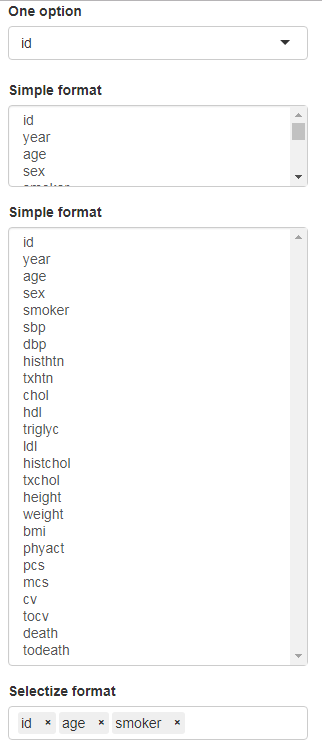

```r
library(compareGroups)
data(regicor)

ui <- fluidPage(

  selectInput("list1", "One option", names(regicor)),

  selectInput("list2", "Simple format", names(regicor),
         multiple=TRUE, selectize=FALSE),

  selectInput("list3", "Simple format", names(regicor),
         multiple=TRUE, size=ncol(regicor), selectize=FALSE),

  selectizeInput("list4", "Selectize format", names(regicor),
         multiple=TRUE,
         options=list(plugins=list('remove_button', 'drag_drop')))
)

server <- function(input, output){}

shinyApp(ui, server)
```

Output elements

Type

Function

Arguments

Example

R-console like text

`verbatimTextOutput`

`outputId`

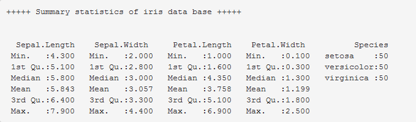

HTML interpreted text

`htmlOutput`

`outputId`, `inline`

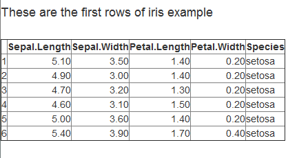

“Regular” table

`tableOutput`

`outputId`

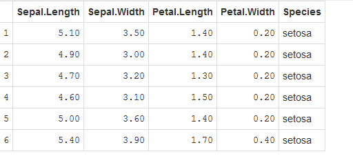

Dynamic table

[`dataTableOutput`](http://rstudio.github.io/DT/)

`outputId`

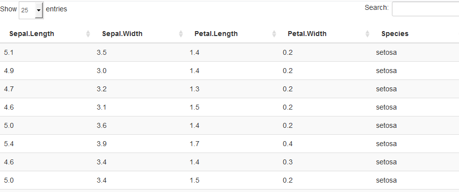

Plots

`plotOutput imageOutput`

`outputId`, `width`, `height`, `click`,…

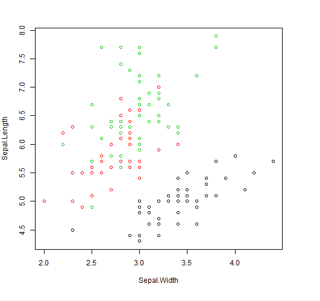

Dynamic plots

[`plotlyOutput`](https://plot.ly/r/)

`outputId`, `width`, `height`, `inline`

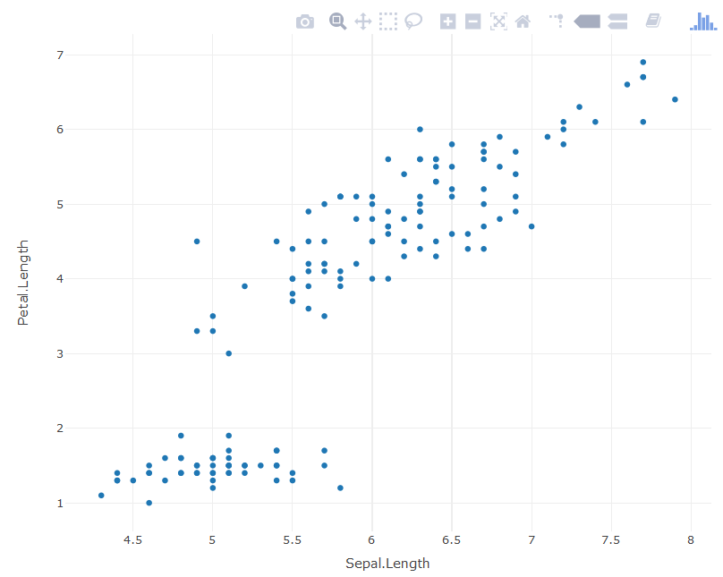

### R-console like text

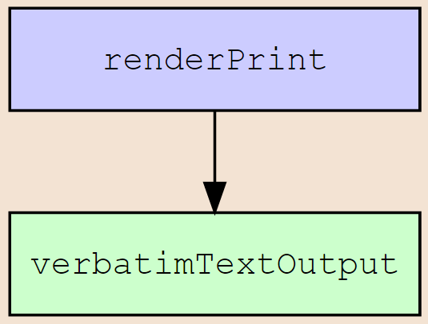

```r
ui <- fluidPage(

  verbatimTextOutput("result")

)

server <- function(input, output) {

  output$result<-renderPrint({
    summary(iris)
  })

}

shinyApp(ui = ui, server = server)
```

### HTML interpreted text

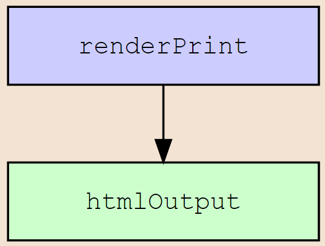

```r
library(xtable)

ui <- fluidPage(

  htmlOutput("result")

)

server <- function(input, output) {

  output$result<-renderPrint({
    print(xtable(head(iris)), type = "html")
  })

}

shinyApp(ui = ui, server = server)
```

**Exercise:** Replace `htmlOutput` by `verbatimTextOutput`

### "Regular" table

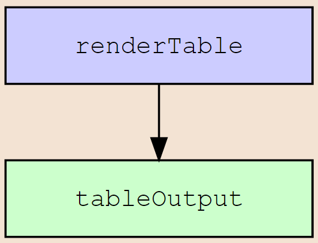

```r
ui <- fluidPage(

  tableOutput("result")

)

server <- function(input, output) {

  output$result<-renderTable({
    head(iris)
  })

}

shinyApp(ui = ui, server = server)
```

### Dynamic table

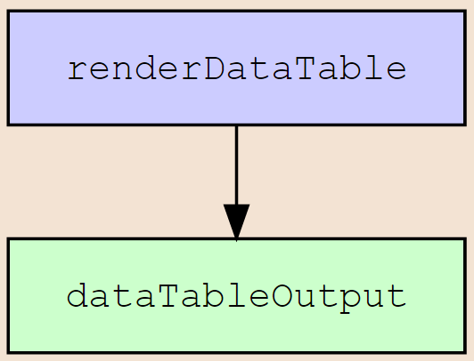

```r
ui <- fluidPage(

  dataTableOutput("result")

)

server <- function(input, output) {

  output$result<-renderDataTable({
    iris
  })

}

shinyApp(ui = ui, server = server)
```

### Dynamic table: extensions

- No need to plug into Shiny app
- Wrap the data.frame using **`datatable`** function from **`DT`** package to add more options (filter, rownames, download buttons, …)
- Execute the following code in R-script or R-markdown.

```r
library(DT)
DT::datatable(iris, filter="top", rownames=FALSE,
    extensions = 'Buttons',
    options = list(dom = 'Bfrtip',
                   buttons = c('copy', 'csv', 'excel', 'pdf', 'print')
              )
)
```

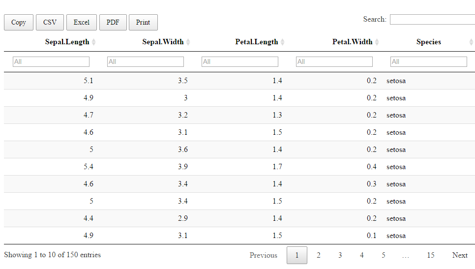

### Plots

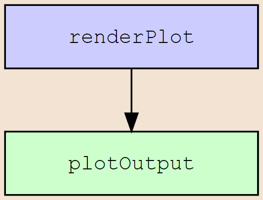

```r
ui <- fluidPage(
  plotOutput("result")
)

server <- function(input, output) {

  output$result<-renderPlot({
    plot(Sepal.Length ~ Sepal.Width,
         col = Species, data = iris)
  }, width = 500, height = 500)

}

shinyApp(ui = ui, server = server)
```

How would the figure look like if width and height are not specified?

### Dynamic plots

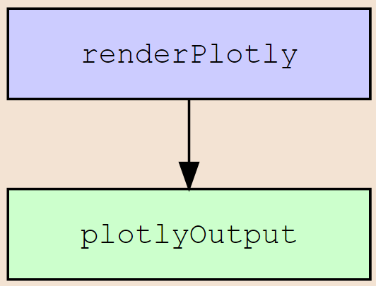

```r
library(plotly)

ui <- fluidPage(

  plotlyOutput("result")

)

server <- function(input, output) {

  output$result<-renderPlotly({
    plot_ly(data=iris, x=~Sepal.Length, y=~Petal.Length)
  })

}

shinyApp(ui = ui, server = server)
```

- As for `datatable`, no need to plug into Shiny app

Layout

### Left and right panels

```r
fluidPage(

  sidebarLayout(

    sidebarPanel(...),

    mainPanel(...)

  )

)
```

- This is the most common option.
- Equivalently, you can also use the function `bootstrapPage` instead of `fluidPage`.

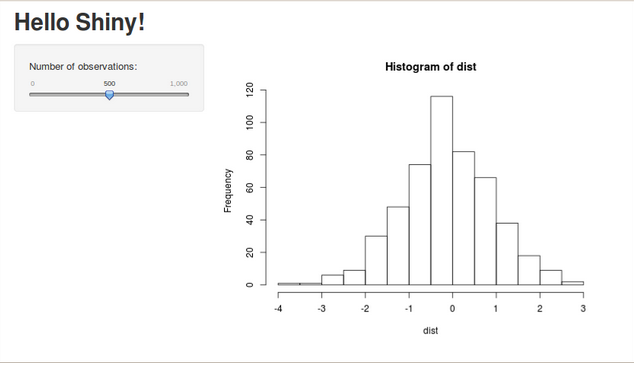

### Rows and columns specification

```r
fluidPage(

  fluidRow(
    column(4, ...),
    column(8, ...)
  ),

  fluidRow(
    column(6, ...),
    ...
  ),
  ...
)
```

- This is the most flexible option.
- You can set the column width.
- Height of columns **can not** be set.
- The sum of columns widths must be 12.
- You can place as many columns as desired, even nested.
- Every row is created by **`fluidRow`** function.

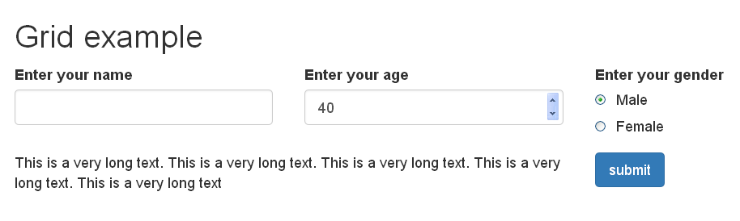

```r
ui <- shinyUI(fluidPage(

  titlePanel("Grid example"),
  ...
  ...

  actionButton("submit","")

))

server <- function(input, output) {}

shinyApp(ui = ui, server = server)
```

**Exercise:** Complete the code to place the elements as in this example

### General menu

```r
navbarPage(

  tabPanel(...),

  tabPanel(...),

)
```

- It is not as frequently used as the previous ones.
- The functionality is the same as for tabs which will be explain below.
- Usefull for “big” applications than can be split in “sub-applications”, one for each general menu tab.

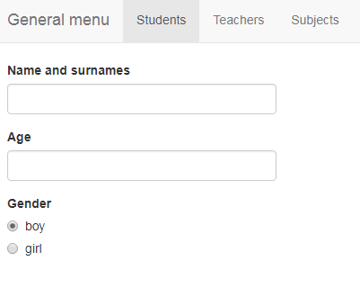

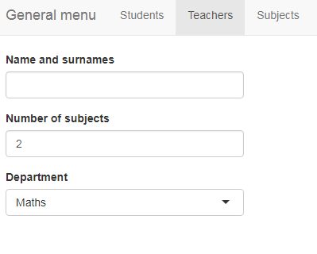

### Tabs

```r
ui <- fluidPage(

  tabsetPanel(id = "menu",

    tabPanel("Table",
    ...
    ),

    tabPanel("Summary",
    ...
    )

  )

)
```

- Elements are arranged one **behind** the other.
- Use **`tabsetPanel`** function to create a set of tabs .
- Use **`tabPanel`** function to create each single tab .

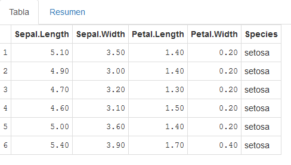

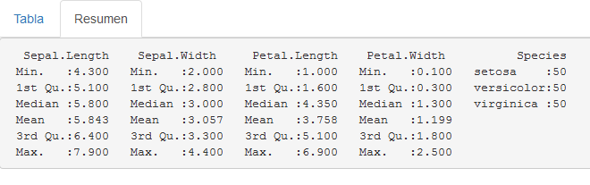

### Merging several tabs (drop-down menu)

```r
ui <- fluidPage(

  tabsetPanel(id="menu", type="pills",

    tabPanel("Tab 1",
      ...
    ),

    navbarMenu("Drop-down",
      tabPanel("Option 1",
        ...
      ),
      tabPanel("Option 2",
        ...
      )
    )

  )
)
```

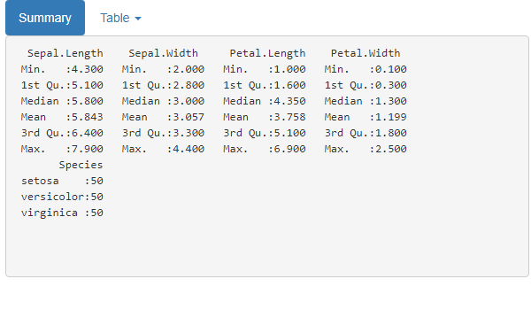

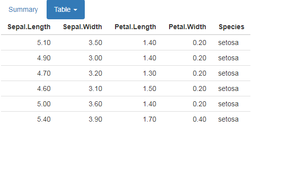

Conditional Panels

### Conditional Panels

- Conditional panels are used when some elements must be shown or not depending on some other input elements values.
- **`conditionalPanel`** function.
  - First argument: character. Logic expression written in **“javascript” language**.
  - Segond argument: form elements that will be appear when the logic expression is TRUE.

```r
conditionalPanel(

  condition = "input.element==1",
  ...

)
```

### Example 1

```r
ui <- fluidPage(
  radioButtons("type",
      "What do you want to show?",
      c("Table"=1, "Summary"=2)),
  conditionalPanel(
    condition = "input.type==1",
    tableOutput("result1")
  ),
  conditionalPanel(
    condition = "input.type==2",
    verbatimTextOutput("result2")
  )
)

server <- function(input, output) {
  output$result1 <- renderTable(
    head(iris)
  )
  output$result2 <- renderPrint(
    summary(iris)
  )
}

shinyApp(ui = ui, server = server)
```

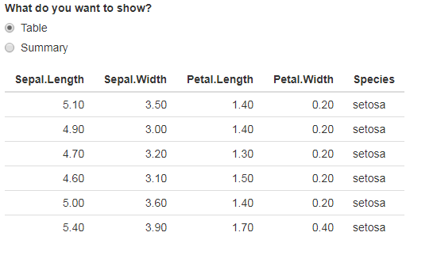

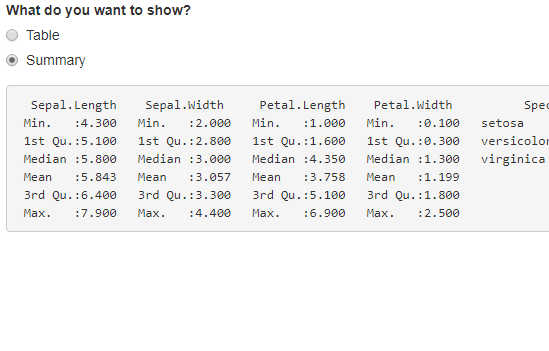

**Exercise:** Reproduce this app using `tabsetPanel`

### Example 2

```r
ui <- fluidPage(

  checkboxInput("help", "Help"),

  conditionalPanel(
    condition = "input.help",
    helpText("This is an explanation
      about how this app works...")
  )

)

server <- function(input, output) {}

shinyApp(ui = ui, server = server)
```

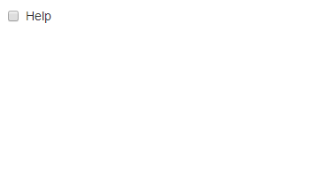

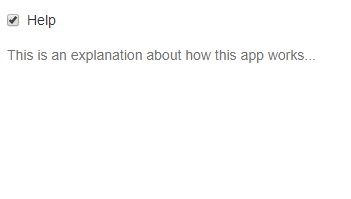

This text appears and disappears clicking on the check box.